# Stat_China

```r
knitr::opts_chunk$set(echo = TRUE, message = FALSE, warning = FALSE)

knitr::opts_knit$set(root.dir = rprojroot::find_rstudio_root_file())
```

Libraries

Load phyloseq - species

```r
load("~/group-project-group-6/project/data/D003924_Diabetes_Mellitus,_T/species/phyloseq.RData")
ps_s <- pylsq
rm(pylsq) # fjerne pylsq, så man kan have mere end et.

# Undersøger phylseq
ps_s
```

```
## phyloseq-class experiment-level object
## otu_table()   OTU Table:         [ 173 taxa and 432 samples ]
## sample_data() Sample Data:       [ 432 samples by 12 sample variables ]
## tax_table()   Taxonomy Table:    [ 173 taxa by 7 taxonomic ranks ]
## phy_tree()    Phylogenetic Tree: [ 173 tips and 59 internal nodes ]
```

```r
rank_names(ps_s)
```

```
## [1] "Domain"  "Phylum"  "Class"   "Order"   "Family"  "Genus"   "Species"
```

```r
sample_variables(ps_s)
```

```
##  [1] "Run.ID"                 "Project.ID"             "Experiment.type"
##  [4] "Nr..reads.sequenced"    "Country"                "Sex"
##  [7] "Host.age"               "BMI"                    "Recent.antibiotics.use"
## [10] "Disease.MESH.ID"        "Disease.name"           "QC.status"
```

```r
# Kun kina
ps_china <- subset_samples(ps_s,
                           Project.ID == "PRJNA422434")

# Undersøger phylseq
ps_china
```

```
## phyloseq-class experiment-level object
## otu_table()   OTU Table:         [ 173 taxa and 359 samples ]
## sample_data() Sample Data:       [ 359 samples by 12 sample variables ]
## tax_table()   Taxonomy Table:    [ 173 taxa by 7 taxonomic ranks ]
## phy_tree()    Phylogenetic Tree: [ 173 tips and 59 internal nodes ]
```

```r
rank_names(ps_china)
```

```
## [1] "Domain"  "Phylum"  "Class"   "Order"   "Family"  "Genus"   "Species"
```

```r
sample_variables(ps_china)
```

```
##  [1] "Run.ID"                 "Project.ID"             "Experiment.type"
##  [4] "Nr..reads.sequenced"    "Country"                "Sex"
##  [7] "Host.age"               "BMI"                    "Recent.antibiotics.use"
## [10] "Disease.MESH.ID"        "Disease.name"           "QC.status"
```

## Visualise community composition

NB! Undersøg relative abundance

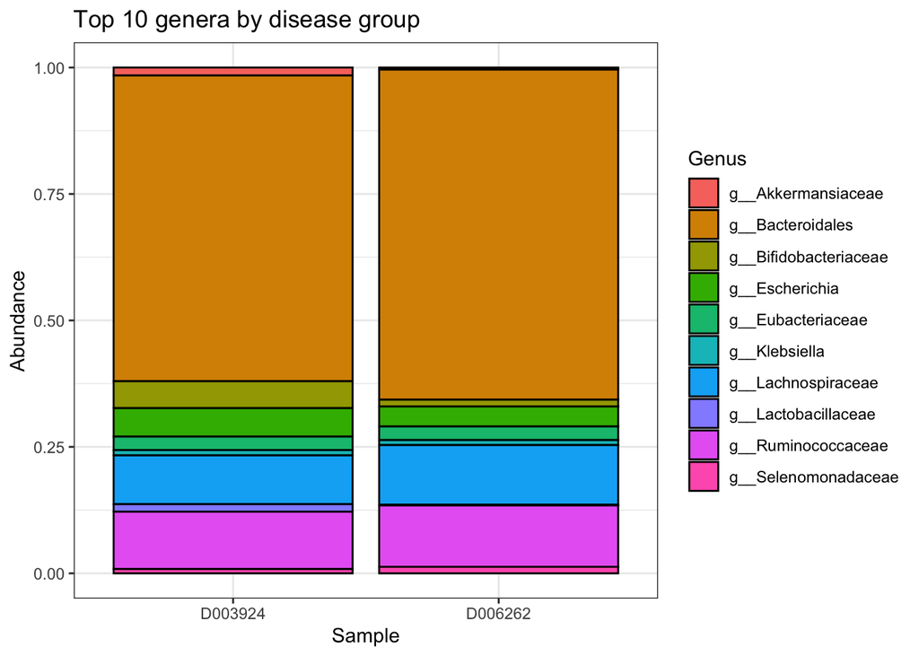

```r
# Step 2 — Convert counts to relative abundance
ps_rel <- transform_sample_counts(ps_china, function(x) x / sum(x))
otu_rel <- as(otu_table(ps_rel), "matrix") %>% t() %>% as.data.frame()
meta_rel <- as(sample_data(ps_rel), "matrix") %>% as.data.frame()
tax_rel <- as(tax_table(ps_rel), "matrix") %>% as.data.frame()

# Step 3 — Aggregate taxa to genus level
ps_genus <- tax_glom(ps_rel, taxrank = "Genus")

#plot_bar(ps_genus, fill = "Genus") +
  #facet_nested(~ Disease.MESH.ID + Sex, scales = "free_x") +
  #theme_bw() +
  #theme(axis.text.x = element_blank())


# Hjælp fra Chat til at samle data fra sample
# Top 10 genera

top10 <- names(sort(
  taxa_sums(ps_genus),
  decreasing = TRUE
))[1:10]

ps_top <- prune_taxa(
  top10,
  ps_genus
)

ps_disease <- merge_samples(
  ps_top,
  group = "Disease.MESH.ID"
)

ps_disease <- transform_sample_counts(
  ps_disease,
  function(x) x / sum(x)
)

plot_bar(
  ps_disease,
  fill = "Genus"
) +
  theme_bw() +
  labs(title = "Top 10 genera by disease group")
```

Der er forskel i taxa abundance

The hidden chunk below creates `dat_rel`, the long relative-abundance table used by the remaining relative-abundance analyses.

# Univariate statistics

Univariate tests are useful because they return concrete candidate taxa, effect sizes and q-values. Their limitation is that they do not directly model the gut microbiome as a coordinated community. That limitation is handled later in the multivariate block.

## Diagnose the data before testing

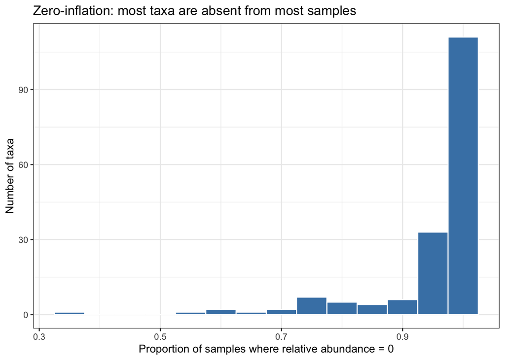

```r
dat_rel %>%
  group_by(taxon) %>%
  summarise(prop_zero = mean(rel_abund == 0), .groups = "drop") %>%
  ggplot(aes(x = prop_zero)) +
    geom_histogram(binwidth = 0.05, fill = "steelblue", color = "white") +
    labs(x = "Proportion of samples where relative abundance = 0",
         y = "Number of taxa",
         title = "Zero-inflation: most taxa are absent from most samples") +
    theme_bw()
```

## Visualise community composition

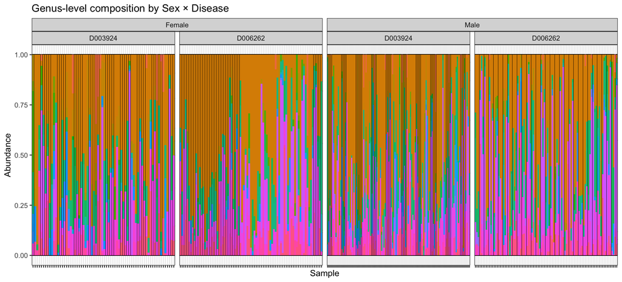

```r
ps_rel  <- transform_sample_counts(ps_china, function(x) x / sum(x))
otu_rel <- as(otu_table(ps_rel), "matrix") %>% t() %>% as.data.frame()
meta_rel <- data.frame(sample_data(ps_rel))
tax_rel  <- as(tax_table(ps_rel), "matrix") %>% as.data.frame()

plot_bar(ps_rel, fill = "Species") +
  geom_bar(aes(fill = Species), stat = "identity", colour = NA) +
  facet_nested(~ Sex + Disease.MESH.ID, scales = "free_x") +
  theme_bw() +
  theme(axis.text.x = element_blank(),
        legend.position = "none") +
  labs(title = "Genus-level composition by Sex × Disease",
       fill = "Genus")
```

# Univariate statistics

## Explore individual taxa

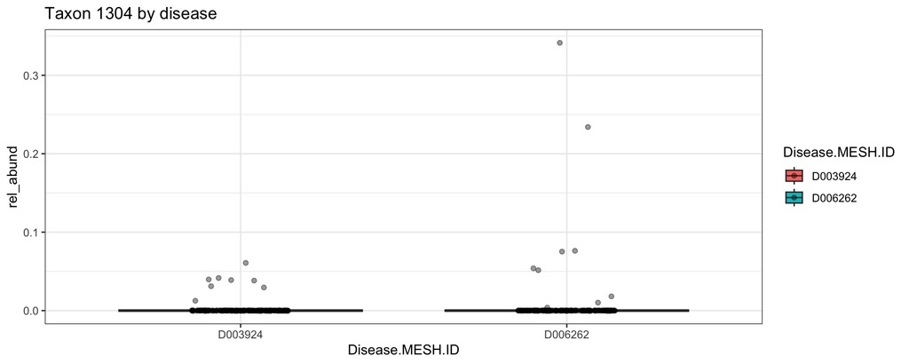

```r
one_taxon <- unique(dat_rel$taxon)[3]
# one_taxon <- unique(dat_rel$taxon)[5]
# one_taxon <- unique(dat_rel$taxon)[20]

# Comparison between disease groups
# fordelingen af én bakteries relative abundance i hver disease-gruppe
# Hver prik er en sample
dat_rel %>%
  filter(taxon == one_taxon) %>%
  ggplot(aes(x = Disease.MESH.ID, y = rel_abund, fill = Disease.MESH.ID)) +
    geom_boxplot(outlier.shape = NA) +
    geom_jitter(width = 0.15, alpha = 0.4) +
    theme_bw() +
    labs(title = paste("Taxon", one_taxon, "by disease"))
```

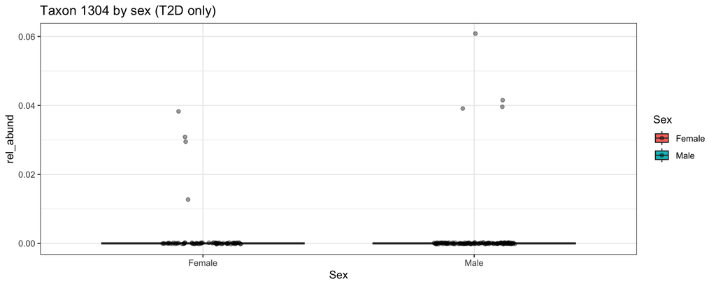

```r
# Comparison between sexes within T2D
# om taxon varierer mellem mænd og kvinder blandt kun T2D-patienter
dat_rel %>%
  filter(taxon == one_taxon, Disease.MESH.ID == "D003924") %>%
  ggplot(aes(x = Sex, y = rel_abund, fill = Sex)) +
    geom_boxplot(outlier.shape = NA) +
    geom_jitter(width = 0.15, alpha = 0.4) +
    theme_bw() +
    labs(title = paste("Taxon", one_taxon, "by sex (T2D only)"))
```

## Diagnose the data before testing

# plottet viser hvor mange taxa der er fraværende (0) i mange samples

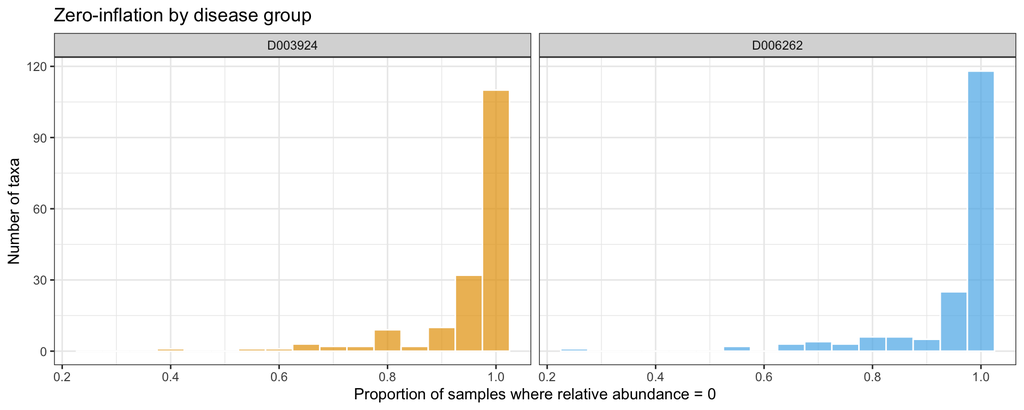

```r
dat_rel %>%
  group_by(taxon, Disease.MESH.ID) %>%
  summarise(prop_zero = mean(rel_abund == 0), .groups = "drop") %>%
  ggplot(aes(x = prop_zero, fill = Disease.MESH.ID)) +
    geom_histogram(binwidth = 0.05, color = "white", alpha = 0.7) +
    scale_fill_manual(values = c("D003924" = "#E69F00", "D006262" = "#56B4E9")) +
    facet_wrap(~ Disease.MESH.ID) +
    labs(x = "Proportion of samples where relative abundance = 0",
         y = "Number of taxa",
         title = "Zero-inflation by disease group") +
    theme_bw() +
    theme(legend.position = "none")
```

### Right skew on a sample of mid-prevalence taxa

# hvordan abundance-fordelingen ser ud for taxa der faktisk findes

# viser at normalfordenlingsantagelse brydes

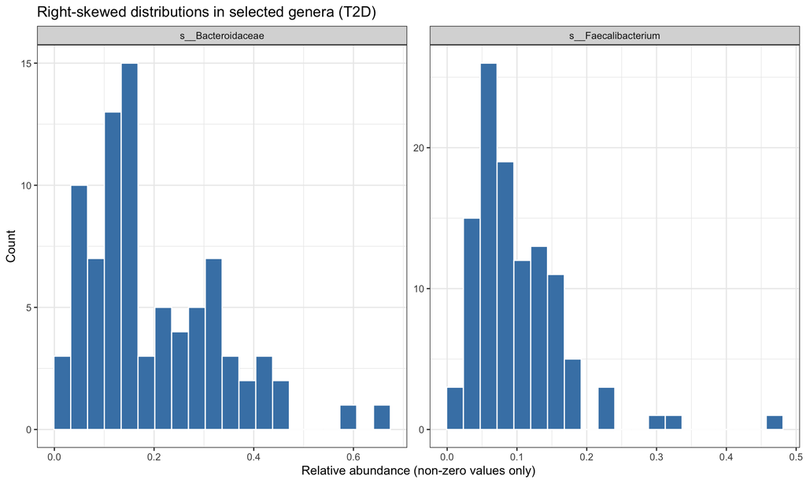

```r
set.seed(42)
example_taxa <- dat_rel %>%
  filter(Disease.MESH.ID == "D003924") %>%
  group_by(taxon, Genus, Species) %>%
  summarise(prop_nonzero = mean(rel_abund > 0), .groups = "drop") %>%
  filter(prop_nonzero > 0.4, prop_nonzero < 0.9) %>%
  slice_sample(n = 6) %>%
  pull(taxon)

dat_rel %>%
  filter(Disease.MESH.ID == "D003924",
         taxon %in% example_taxa,
         rel_abund > 0) %>%
  mutate(label = Species) %>%
  ggplot(aes(x = rel_abund)) +
    geom_histogram(bins = 20, fill = "steelblue", color = "white") +
    facet_wrap(~ label, scales = "free") +
    labs(x = "Relative abundance (non-zero values only)",
         y = "Count",
         title = "Right-skewed distributions in selected genera (T2D)") +
    theme_bw()
```

```r
# y = count --> = hvor mange samples der har den abundance.
```

# undersøger om data er normalfordelt

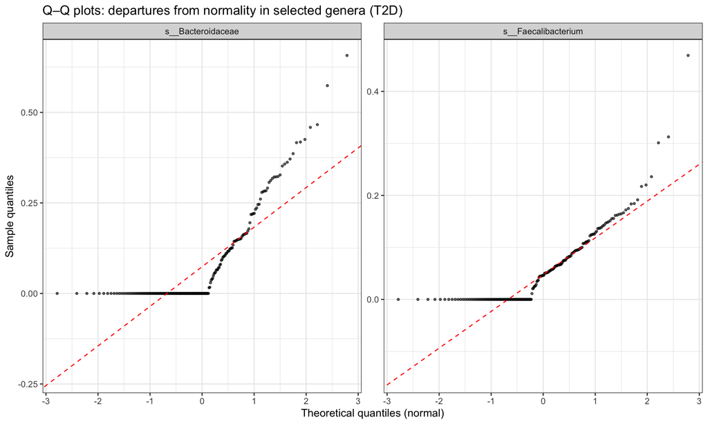

```r
dat_rel %>%
  filter(Disease.MESH.ID == "D003924", taxon %in% example_taxa) %>%
  mutate(label = Species) %>%
  ggplot(aes(sample = rel_abund)) +
    stat_qq(size = 0.8, alpha = 0.6) +
    stat_qq_line(color = "red", linetype = "dashed") +
    facet_wrap(~ label, scales = "free") +
    labs(x = "Theoretical quantiles (normal)",
         y = "Sample quantiles",
         title = "Q–Q plots: departures from normality in selected genera (T2D)") +
    theme_bw()
```

Q–Q plottet ser på: fordelingen af relative abundances for én taxon og sammenligner den med: en teoretisk normalfordeling

Konklusion: Zero-inflation, right skew and Q-Q curvature together justify rank-based or compositional methods over raw t-tests.

## Wilcoxon rank-sum test

```r
wilcox_results <- dat_rel %>%
  group_by(taxon, Genus, Species) %>%
  summarise(
    p_value      = wilcox.test(rel_abund ~ Disease.MESH.ID, exact = FALSE)$p.value,
    mean_T2D     = mean(rel_abund[Disease.MESH.ID == "D003924"]),
    mean_Healthy = mean(rel_abund[Disease.MESH.ID == "D006262"]),
    log2_fc      = log2((mean_T2D + 1e-6) / (mean_Healthy + 1e-6)),
    .groups = "drop"
  ) %>%
  mutate(q_value = p.adjust(p_value, method = "BH"))

head(wilcox_results, 10)
```

```
## # A tibble: 10 × 8
##    taxon   Genus          Species  p_value mean_T2D mean_Healthy log2_fc q_value
##    <chr>   <chr>          <chr>      <dbl>    <dbl>        <dbl>   <dbl>   <dbl>
##  1 100884  g__Erysipelot… s__Cop… NaN      0            0          0     NaN
##  2 100886  g__Erysipelot… s__Cat… NaN      0            0          0     NaN
##  3 102684  g__Streptococ… s__Str…   0.300  0            0.000104  -6.71    0.502
##  4 103892  g__Veillonell… s__Vei…   0.340  0.000158     0          7.31    0.502
##  5 105841  g__Lachnospir… s__Ana… NaN      0            0          0     NaN
##  6 1099853 g__Bacteroida… s__Bar…   0.176  0.000641     0          9.33    0.502
##  7 1118061 g__Bacteroida… s__Rik…   0.0544 0.00110      0         10.1     0.359
##  8 1203555 g__Acidaminoc… s__Aci… NaN      0            0          0     NaN
##  9 1211813 g__Bacteroida… s__Rik…   0.340  0.000354     0          8.47    0.502
## 10 1226323 g__Oscillospi… s__Osc…   0.959  0.000188     0.000136   0.460   0.959
```

`log2_fc > 0` → T2D-enriched. `log2_fc < 0` → T2D-depleted.

Der udføres en Wilcoxon rank-sum test for hver taxon mellem T2D og raske samples. p_value viser hvor sandsynligt det er, at forskellen mellem grupperne skyldes tilfældighed. log2_fc viser effektretningen: positive værdier betyder højere abundance i T2D, negative betyder lavere abundance i T2D. q_value er FDR-korrigerede p-værdier og bruges til at kontrollere for multiple testing.

### Top T2D-depleted (Wilcoxon)

```r
wilcox_T2D_depleted <- wilcox_results %>%
  select(taxon, Genus, Species, mean_T2D, mean_Healthy, log2_fc, p_value, q_value) %>%
  arrange(log2_fc) %>%
  head(10)

wilcox_T2D_depleted
```

```
## # A tibble: 10 × 8
##    taxon  Genus            Species mean_T2D mean_Healthy log2_fc p_value q_value
##    <chr>  <chr>            <chr>      <dbl>        <dbl>   <dbl>   <dbl>   <dbl>
##  1 33043  g__Lachnospirac… s__Cop…        0     0.000751   -9.55  0.141    0.502
##  2 658089 g__Lachnospirac… s__unc…        0     0.000652   -9.35  0.0706   0.373
##  3 28126  g__Bacteroidales s__Pre…        0     0.000628   -9.30  0.300    0.502
##  4 1535   g__Ruminococcac… s__unc…        0     0.000525   -9.04  0.300    0.502
##  5 384638 g__unclassified… s__[Ba…        0     0.000512   -9.00  0.300    0.502
##  6 36834  g__Clostridiace… s__Clo…        0     0.000397   -8.64  0.300    0.502
##  7 457394 g__Bacteroidales s__Bac…        0     0.000388   -8.60  0.300    0.502
##  8 469593 g__Bacteroidales s__Bac…        0     0.000356   -8.48  0.300    0.502
##  9 548    g__Klebsiella    s__Kle…        0     0.000274   -8.10  0.141    0.502
## 10 39486  g__Lachnospirac… s__Dor…        0     0.000234   -7.88  0.300    0.502
```

Dette er en tabel over de taxa som er mest reducerede i T2D sammenlignet med raske kontroller. Taxaene sorteres efter log2_fc, hvor de mest negative værdier vises øverst. mean_T2D og mean_Healthy viser den gennemsnitlige relative abundance i hver gruppe. En negativ log2_fc betyder at bakterien er mindre abundant i T2D-gruppen. p_value og q_value viser hvor statistisk stærk forskellen er efter multiple testing-korrektion.

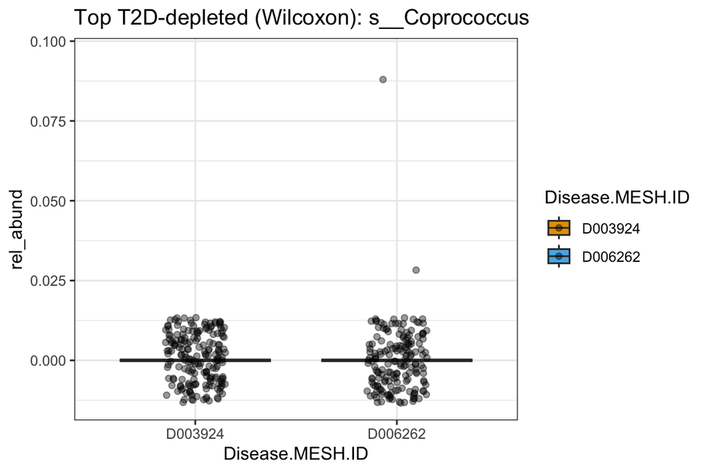

```r
top_taxon <- wilcox_T2D_depleted %>% slice(1) %>% pull(taxon)
top_label <- wilcox_T2D_depleted %>% slice(1) %>% pull(Species)

dat_rel %>%
  filter(taxon == top_taxon) %>%
  ggplot(aes(x = Disease.MESH.ID, y = rel_abund, fill = Disease.MESH.ID)) +
    geom_boxplot(outlier.shape = NA) +
    geom_jitter(width = 0.15, alpha = 0.4) +
    scale_fill_manual(values = c("D003924" = "#E69F00", "D006262" = "#56B4E9")) +
    theme_bw() +
    labs(title = paste("Top T2D-depleted (Wilcoxon):", top_label))
```

Dette plot viser den taxon som er mest “depleted” i T2D ifølge Wilcoxon-analysen. X-aksen viser disease-grupperne (T2D vs raske), mens y-aksen viser taxonens relative abundance. Hver prik repræsenterer ét biologisk sample/individ, og boxplottet opsummerer gruppens fordeling. Hvis T2D-gruppen ligger lavere på y-aksen, betyder det at bakterien findes i lavere mængde hos T2D-patienter. Plottet bruges til visuelt at vurdere effektstørrelse, variation og overlap mellem grupperne — ikke kun statistisk signifikans.

### Top T2D-enriched (Wilcoxon)

```r
wilcox_T2D_enriched <- wilcox_results %>%
  select(taxon, Genus, Species, mean_T2D, mean_Healthy, log2_fc, p_value, q_value) %>%
  arrange(-log2_fc) %>%
  head(10)

wilcox_T2D_enriched
```

```
## # A tibble: 10 × 8
##    taxon   Genus           Species mean_T2D mean_Healthy log2_fc p_value q_value
##    <chr>   <chr>           <chr>      <dbl>        <dbl>   <dbl>   <dbl>   <dbl>
##  1 1604    g__Lactobacill… s__Lac… 0.00465             0   12.2   0.0312   0.323
##  2 626932  g__Bacteroidal… s__Rik… 0.00187             0   10.9   0.0312   0.323
##  3 97478   g__Lactobacill… s__Lac… 0.00162             0   10.7   0.0106   0.182
##  4 45851   g__Lachnospira… s__But… 0.00160             0   10.6   0.340    0.502
##  5 328812  g__Bacteroidal… s__Tan… 0.00141             0   10.5   0.0964   0.393
##  6 1596    g__Lactobacill… s__Lac… 0.00112             0   10.1   0.340    0.502
##  7 33959   g__Lactobacill… s__Lac… 0.00111             0   10.1   0.0964   0.393
##  8 665956  g__Ruminococca… s__Sub… 0.00111             0   10.1   0.0544   0.359
##  9 1118061 g__Bacteroidal… s__Rik… 0.00110             0   10.1   0.0544   0.359
## 10 626935  g__Coriobacter… s__Col… 0.000918            0    9.84  0.340    0.502
```

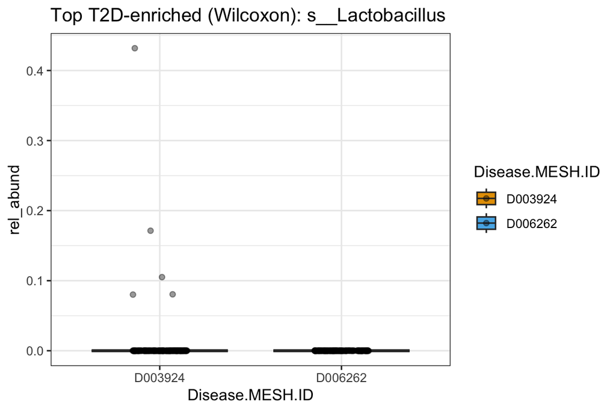

```r
top_taxon <- wilcox_T2D_enriched %>% slice(1) %>% pull(taxon)
top_label <- wilcox_T2D_enriched %>% slice(1) %>% pull(Species)

dat_rel %>%
  filter(taxon == top_taxon) %>%
  ggplot(aes(x = Disease.MESH.ID, y = rel_abund, fill = Disease.MESH.ID)) +
    geom_boxplot(outlier.shape = NA) +
    geom_jitter(width = 0.15, alpha = 0.4) +
    scale_fill_manual(values = c("D003924" = "#E69F00", "D006262" = "#56B4E9")) +
    theme_bw() +
    labs(title = paste("Top T2D-enriched (Wilcoxon):", top_label))
```

### Volcano plot — Wilcoxon

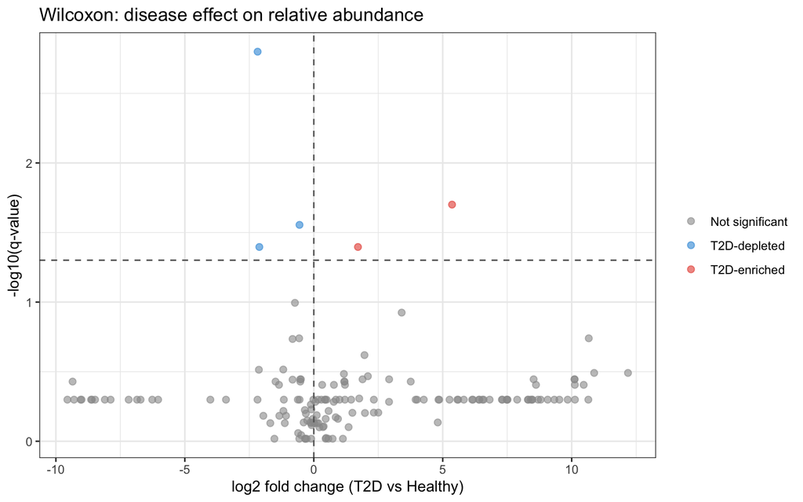

```r
wilcox_results %>%
  mutate(
    neg_log10_q = -log10(q_value),
    direction = case_when(
      q_value < 0.05 & log2_fc > 0 ~ "T2D-enriched",
      q_value < 0.05 & log2_fc < 0 ~ "T2D-depleted",
      TRUE                         ~ "Not significant"
    )
  ) %>%
  ggplot(aes(x = log2_fc, y = neg_log10_q, color = direction)) +
    geom_point(alpha = 0.6, size = 2) +
    scale_color_manual(values = c("T2D-enriched" = "#E74C3C",
                                  "T2D-depleted" = "#3498DB",
                                  "Not significant" = "grey60")) +
    geom_hline(yintercept = -log10(0.05), linetype = "dashed", color = "grey40") +
    geom_vline(xintercept = 0, linetype = "dashed", color = "grey40") +
    labs(x = "log2 fold change (T2D vs Healthy)",
         y = "-log10(q-value)", color = NULL,
         title = "Wilcoxon: disease effect on relative abundance") +
    theme_bw()
```

Dette er et volcano plot, som bruges til at kombinere effektstørrelse og statistisk signifikans for alle taxa samtidigt. X-aksen viser log2 fold change, hvor positive værdier betyder højere abundance i T2D og negative værdier betyder lavere abundance i T2D. Y-aksen viser -log10(q-value), så punkter højere oppe er mere statistisk signifikante. Hver prik repræsenterer én taxon, og farverne viser om taxa er T2D-enriched, T2D-depleted eller ikke signifikant. Plottet bruges til hurtigt at identificere de taxa som både har store biologiske forskelle og stærk statistisk evidens.

# Navne på signifikante

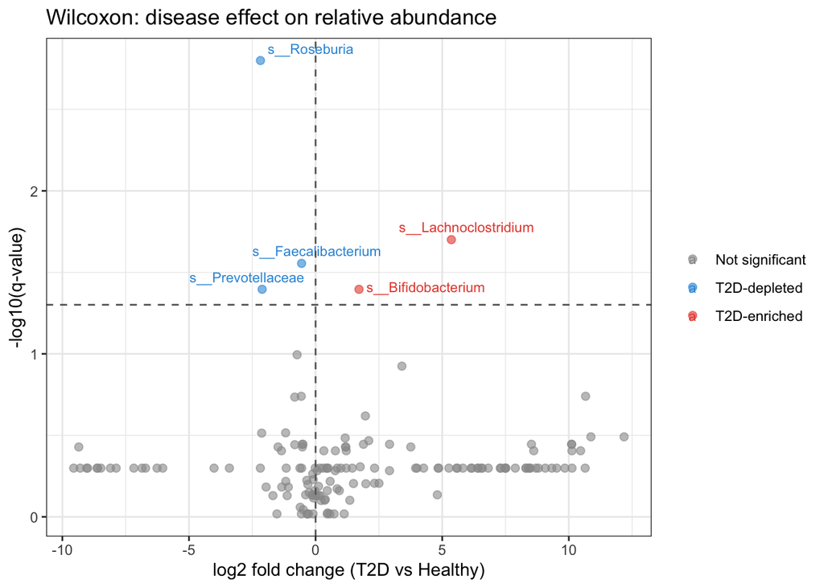

```r
library(ggrepel)

wilcox_results %>%
  mutate(
    neg_log10_q = -log10(q_value),

    direction = case_when(
      q_value < 0.05 & log2_fc > 0 ~ "T2D-enriched",
      q_value < 0.05 & log2_fc < 0 ~ "T2D-depleted",
      TRUE                         ~ "Not significant"
    ),

    label = ifelse(
      q_value < 0.05,
      Species,
      NA
    )
  ) %>%

  ggplot(aes(x = log2_fc,
             y = neg_log10_q,
             color = direction)) +

    geom_point(alpha = 0.6,
               size = 2) +

    geom_text_repel(
      aes(label = label),
      size = 3,
      max.overlaps = 25
    ) +

    scale_color_manual(
      values = c(
        "T2D-enriched" = "#E74C3C",
        "T2D-depleted" = "#3498DB",
        "Not significant" = "grey60"
      )
    ) +

    geom_hline(
      yintercept = -log10(0.05),
      linetype = "dashed",
      color = "grey40"
    ) +

    geom_vline(
      xintercept = 0,
      linetype = "dashed",
      color = "grey40"
    ) +

    labs(
      x = "log2 fold change (T2D vs Healthy)",
      y = "-log10(q-value)",
      color = NULL,
      title = "Wilcoxon: disease effect on relative abundance"
    ) +

    theme_bw()
```

### Bar chart of top Wilcoxon hits

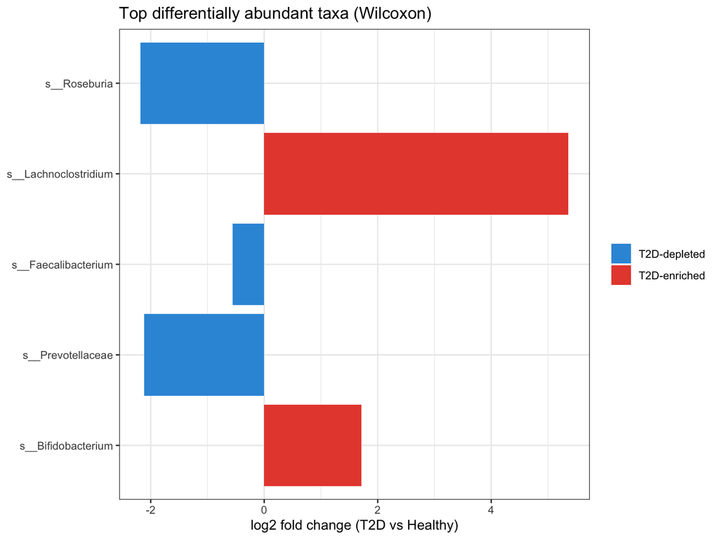

```r
bind_rows(
  wilcox_results %>% filter(q_value < 0.05) %>% arrange(log2_fc)  %>% head(10),
  wilcox_results %>% filter(q_value < 0.05) %>% arrange(-log2_fc) %>% head(10)
) %>%
  distinct() %>%
  mutate(
    label = Species,
    direction = ifelse(log2_fc > 0, "T2D-enriched", "T2D-depleted")
  ) %>%
  ggplot(aes(x = reorder(label, -q_value), y = log2_fc, fill = direction)) +
    geom_col() +
    coord_flip() +
    scale_fill_manual(values = c("T2D-enriched" = "#E74C3C", "T2D-depleted" = "#3498DB")) +
    labs(x = NULL, y = "log2 fold change (T2D vs Healthy)", fill = NULL,
         title = "Top differentially abundant taxa (Wilcoxon)") +
    theme_bw()
```

Dette plot viser de mest differentielt abundante taxa mellem T2D og raske kontroller. Hver søjle repræsenterer én taxon/species, og y-aksen viser log2 fold change mellem grupperne. Positive værdier betyder at taxon er mere abundant i T2D, mens negative værdier betyder at den er mindre abundant i T2D. Farverne adskiller T2D-enriched taxa fra T2D-depleted taxa. Plottet bruges til at identificere hvilke bakterier der har de største biologiske forskelle mellem sygdomsgrupperne.

## Disease effect using log-transformed linear models

```r
glm_disease_results <- dat_rel %>%
  mutate(Disease.MESH.ID = factor(Disease.MESH.ID, levels = c("D006262", "D003924"))) %>%
  group_by(taxon, Genus, Species) %>%
  group_modify(~ {
    fit <- glm(log10(rel_abund + 1e-6) ~ Disease.MESH.ID,
               data = .x, family = gaussian())
    broom::tidy(fit)
  }) %>%
  ungroup() %>%
  filter(term == "Disease.MESH.IDD003924") %>%
  mutate(
    q_value = p.adjust(p.value, method = "BH"),
    fold_change_T2D_vs_Healthy = 10^estimate
  )
```

Positive estimate = T2D-enriched on the log10 scale.

### Top T2D-depleted (GLM)

```r
glm_T2D_depleted <- glm_disease_results %>%
  select(taxon, Genus, Species, estimate, fold_change_T2D_vs_Healthy,
         std.error, statistic, p.value, q_value) %>%
  arrange(fold_change_T2D_vs_Healthy) %>%
  head(10)

glm_T2D_depleted
```

```
## # A tibble: 10 × 9
##    taxon  Genus      Species estimate fold_change_T2D_vs_H…¹ std.error statistic
##    <chr>  <chr>      <chr>      <dbl>                  <dbl>     <dbl>     <dbl>
##  1 853    g__Rumino… s__Fae…   -0.809                  0.155     0.246     -3.29
##  2 166486 g__Lachno… s__Ros…   -0.771                  0.170     0.170     -4.54
##  3 39491  g__Lachno… s__unc…   -0.713                  0.193     0.236     -3.02
##  4 821    g__Bacter… s__Bac…   -0.635                  0.232     0.252     -2.51
##  5 360807 g__Lachno… s__Ros…   -0.588                  0.258     0.217     -2.71
##  6 363265 g__Bacter… s__Pre…   -0.517                  0.304     0.156     -3.32
##  7 165179 g__Bacter… s__Pre…   -0.419                  0.381     0.248     -1.69
##  8 310297 g__Bacter… s__Bac…   -0.392                  0.406     0.213     -1.83
##  9 310298 g__Bacter… s__Bac…   -0.356                  0.441     0.186     -1.92
## 10 39485  g__Eubact… s__Eub…   -0.301                  0.500     0.224     -1.34
## # ℹ abbreviated name: ¹fold_change_T2D_vs_Healthy
## # ℹ 2 more variables: p.value <dbl>, q_value <dbl>
```

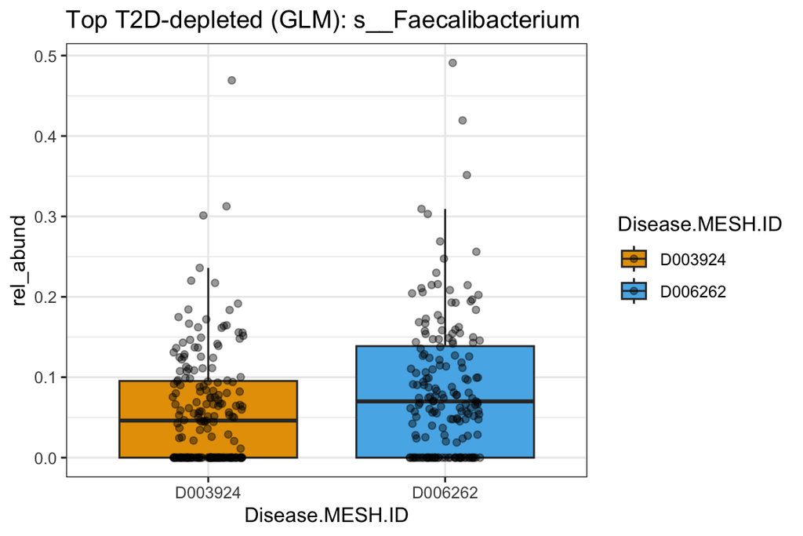

```r
top_taxon <- glm_T2D_depleted %>% slice(1) %>% pull(taxon)
top_label <- glm_T2D_depleted %>% slice(1) %>% pull(Species)

dat_rel %>%
  filter(taxon == top_taxon) %>%
  ggplot(aes(x = Disease.MESH.ID, y = rel_abund, fill = Disease.MESH.ID)) +
    geom_boxplot(outlier.shape = NA) +
    geom_jitter(width = 0.15, alpha = 0.4) +
    scale_fill_manual(values = c("D003924" = "#E69F00", "D006262" = "#56B4E9")) +
    theme_bw() +
    labs(title = paste("Top T2D-depleted (GLM):", top_label))
```

### Top T2D-enriched (GLM)

```r
glm_T2D_enriched <- glm_disease_results %>%
  select(taxon, Genus, Species, estimate, fold_change_T2D_vs_Healthy,
         std.error, statistic, p.value, q_value) %>%
  arrange(-fold_change_T2D_vs_Healthy) %>%
  head(10)

glm_T2D_enriched
```

```
## # A tibble: 10 × 9
##    taxon  Genus      Species estimate fold_change_T2D_vs_H…¹ std.error statistic
##    <chr>  <chr>      <chr>      <dbl>                  <dbl>     <dbl>     <dbl>
##  1 216816 g__Bifido… s__Bif…    0.529                   3.38    0.163       3.24
##  2 208479 g__Lachno… s__Lac…    0.469                   2.94    0.124       3.79
##  3 46503  g__Bacter… s__Tan…    0.397                   2.50    0.187       2.12
##  4 357276 g__Bacter… s__Bac…    0.395                   2.48    0.226       1.75
##  5 40518  g__Rumino… s__Rum…    0.361                   2.30    0.224       1.61
##  6 47678  g__Bacter… s__Bac…    0.351                   2.24    0.221       1.58
##  7 239935 g__Akkerm… s__Akk…    0.325                   2.12    0.132       2.46
##  8 562    g__Escher… s__Esc…    0.279                   1.90    0.244       1.14
##  9 1685   g__Bifido… s__Bif…    0.275                   1.88    0.0985      2.79
## 10 246787 g__Bacter… s__Bac…    0.267                   1.85    0.149       1.79
## # ℹ abbreviated name: ¹fold_change_T2D_vs_Healthy
## # ℹ 2 more variables: p.value <dbl>, q_value <dbl>
```

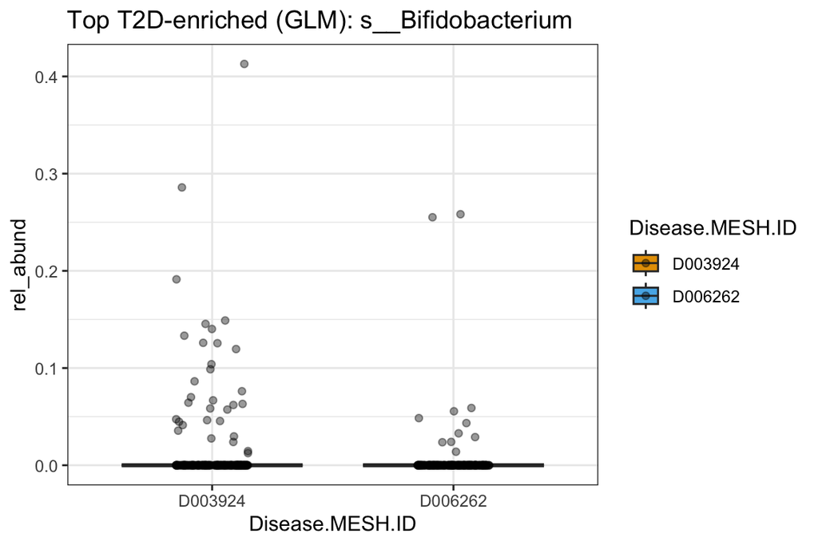

```r
top_taxon <- glm_T2D_enriched %>% slice(1) %>% pull(taxon)
top_label <- glm_T2D_enriched %>% slice(1) %>% pull(Species)

dat_rel %>%
  filter(taxon == top_taxon) %>%
  ggplot(aes(x = Disease.MESH.ID, y = rel_abund, fill = Disease.MESH.ID)) +
    geom_boxplot(outlier.shape = NA) +
    geom_jitter(width = 0.15, alpha = 0.4) +
    scale_fill_manual(values = c("D003924" = "#E69F00", "D006262" = "#56B4E9")) +
    theme_bw() +
    labs(title = paste("Top T2D-enriched (GLM):", top_label))
```

### Volcano plot — GLM (unadjusted)

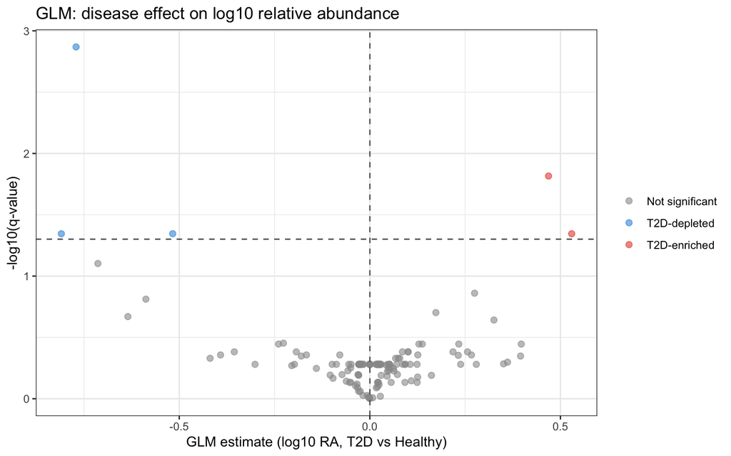

```r
glm_disease_results %>%
  mutate(
    neg_log10_q = -log10(q_value),
    direction = case_when(
      q_value < 0.05 & estimate > 0 ~ "T2D-enriched",
      q_value < 0.05 & estimate < 0 ~ "T2D-depleted",
      TRUE                          ~ "Not significant"
    )
  ) %>%
  ggplot(aes(x = estimate, y = neg_log10_q, color = direction)) +
    geom_point(alpha = 0.6, size = 2) +
    scale_color_manual(values = c("T2D-enriched" = "#E74C3C",
                                  "T2D-depleted" = "#3498DB",
                                  "Not significant" = "grey60")) +
    geom_hline(yintercept = -log10(0.05), linetype = "dashed", color = "grey40") +
    geom_vline(xintercept = 0, linetype = "dashed", color = "grey40") +
    labs(x = "GLM estimate (log10 RA, T2D vs Healthy)",
         y = "-log10(q-value)", color = NULL,
         title = "GLM: disease effect on log10 relative abundance") +
    theme_bw()
```

### Bar chart — GLM top hits

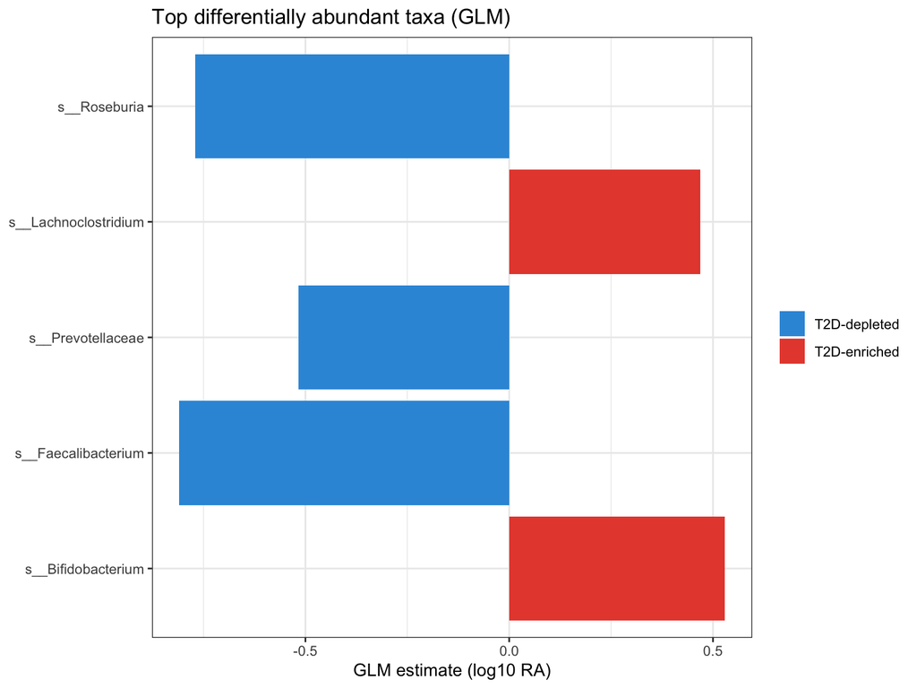

```r
bind_rows(
  glm_disease_results %>% filter(q_value < 0.05) %>% arrange(estimate)  %>% head(10),
  glm_disease_results %>% filter(q_value < 0.05) %>% arrange(-estimate) %>% head(10)
) %>%
  distinct() %>%
  mutate(
    label = Species,
    direction = ifelse(estimate > 0, "T2D-enriched", "T2D-depleted")
  ) %>%
  ggplot(aes(x = reorder(label, -q_value), y = estimate, fill = direction)) +
    geom_col() +
    coord_flip() +
    scale_fill_manual(values = c("T2D-enriched" = "#E74C3C", "T2D-depleted" = "#3498DB")) +
    labs(x = NULL, y = "GLM estimate (log10 RA)", fill = NULL,
         title = "Top differentially abundant taxa (GLM)") +
    theme_bw()
```

## Adjust the linear model for Sex

```r
glm_disease_adjusted_sex_results <- dat_rel %>%
  mutate(
    Disease.MESH.ID = factor(Disease.MESH.ID, levels = c("D006262", "D003924")),
    Sex             = factor(Sex,             levels = c("Female", "Male"))
  ) %>%
  group_by(taxon, Genus, Species) %>%
  group_modify(~ {
    fit <- glm(log10(rel_abund + 1e-6) ~ Disease.MESH.ID + Sex,
               data = .x, family = gaussian())
    broom::tidy(fit)
  }) %>%
  ungroup() %>%
  filter(term == "Disease.MESH.IDD003924") %>%
  mutate(
    q_value = p.adjust(p.value, method = "BH"),
    fold_change_T2D_vs_Healthy_adj = 10^estimate
  )
```

### Top T2D-depleted (GLM adjusted for Sex)

```r
glm_adj_T2D_depleted <- glm_disease_adjusted_sex_results %>%
  select(taxon, Genus, Species, estimate, fold_change_T2D_vs_Healthy_adj,
         std.error, statistic, p.value, q_value) %>%
  arrange(fold_change_T2D_vs_Healthy_adj) %>%
  head(10)

glm_adj_T2D_depleted
```

```
## # A tibble: 10 × 9
##    taxon  Genus      Species estimate fold_change_T2D_vs_H…¹ std.error statistic
##    <chr>  <chr>      <chr>      <dbl>                  <dbl>     <dbl>     <dbl>
##  1 853    g__Rumino… s__Fae…   -0.819                  0.152     0.247     -3.31
##  2 166486 g__Lachno… s__Ros…   -0.752                  0.177     0.171     -4.40
##  3 39491  g__Lachno… s__unc…   -0.742                  0.181     0.238     -3.12
##  4 360807 g__Lachno… s__Ros…   -0.622                  0.239     0.218     -2.85
##  5 821    g__Bacter… s__Bac…   -0.609                  0.246     0.254     -2.40
##  6 363265 g__Bacter… s__Pre…   -0.544                  0.286     0.157     -3.48
##  7 165179 g__Bacter… s__Pre…   -0.460                  0.346     0.249     -1.85
##  8 310297 g__Bacter… s__Bac…   -0.421                  0.379     0.215     -1.96
##  9 310298 g__Bacter… s__Bac…   -0.379                  0.418     0.187     -2.03
## 10 39485  g__Eubact… s__Eub…   -0.270                  0.537     0.225     -1.20
## # ℹ abbreviated name: ¹fold_change_T2D_vs_Healthy_adj
## # ℹ 2 more variables: p.value <dbl>, q_value <dbl>
```

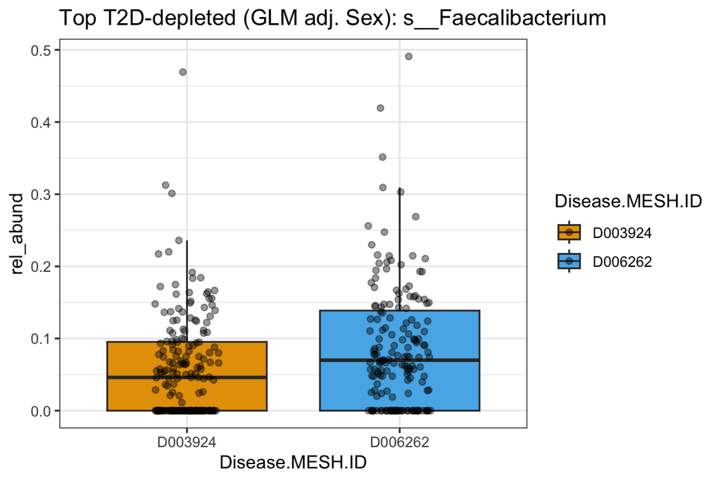

```r
top_taxon <- glm_adj_T2D_depleted %>% slice(1) %>% pull(taxon)
top_label <- glm_adj_T2D_depleted %>% slice(1) %>% pull(Species)

dat_rel %>%
  filter(taxon == top_taxon) %>%
  ggplot(aes(x = Disease.MESH.ID, y = rel_abund, fill = Disease.MESH.ID)) +
    geom_boxplot(outlier.shape = NA) +
    geom_jitter(width = 0.15, alpha = 0.4) +
    scale_fill_manual(values = c("D003924" = "#E69F00", "D006262" = "#56B4E9")) +
    theme_bw() +
    labs(title = paste("Top T2D-depleted (GLM adj. Sex):", top_label))
```

### Top T2D-enriched (GLM adjusted for Sex)

```r
glm_adj_T2D_enriched <- glm_disease_adjusted_sex_results %>%
  select(taxon, Genus, Species, estimate, fold_change_T2D_vs_Healthy_adj,
         std.error, statistic, p.value, q_value) %>%
  arrange(-fold_change_T2D_vs_Healthy_adj) %>%
  head(10)

glm_adj_T2D_enriched
```

```
## # A tibble: 10 × 9
##    taxon  Genus      Species estimate fold_change_T2D_vs_H…¹ std.error statistic
##    <chr>  <chr>      <chr>      <dbl>                  <dbl>     <dbl>     <dbl>
##  1 216816 g__Bifido… s__Bif…    0.524                   3.34    0.165       3.18
##  2 208479 g__Lachno… s__Lac…    0.473                   2.97    0.125       3.79
##  3 357276 g__Bacter… s__Bac…    0.465                   2.92    0.225       2.07
##  4 46503  g__Bacter… s__Tan…    0.398                   2.50    0.189       2.11
##  5 40518  g__Rumino… s__Rum…    0.358                   2.28    0.226       1.59
##  6 239935 g__Akkerm… s__Akk…    0.331                   2.14    0.133       2.48
##  7 47678  g__Bacter… s__Bac…    0.330                   2.14    0.223       1.48
##  8 1685   g__Bifido… s__Bif…    0.305                   2.02    0.0981      3.11
##  9 246787 g__Bacter… s__Bac…    0.292                   1.96    0.149       1.96
## 10 39492  g__Rumino… s__unc…    0.284                   1.92    0.130       2.18
## # ℹ abbreviated name: ¹fold_change_T2D_vs_Healthy_adj
## # ℹ 2 more variables: p.value <dbl>, q_value <dbl>
```

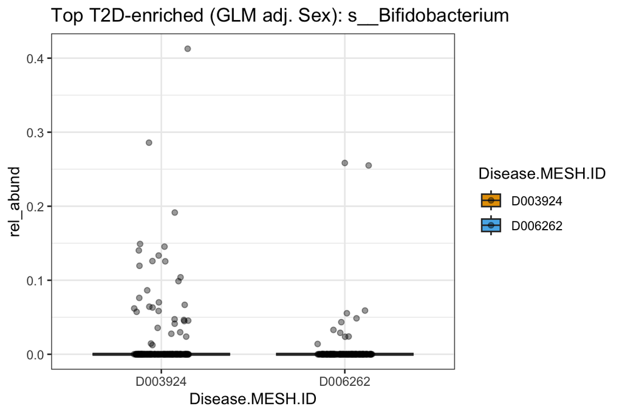

```r
top_taxon <- glm_adj_T2D_enriched %>% slice(1) %>% pull(taxon)
top_label <- glm_adj_T2D_enriched %>% slice(1) %>% pull(Species)

dat_rel %>%
  filter(taxon == top_taxon) %>%
  ggplot(aes(x = Disease.MESH.ID, y = rel_abund, fill = Disease.MESH.ID)) +
    geom_boxplot(outlier.shape = NA) +
    geom_jitter(width = 0.15, alpha = 0.4) +
    scale_fill_manual(values = c("D003924" = "#E69F00", "D006262" = "#56B4E9")) +
    theme_bw() +
    labs(title = paste("Top T2D-enriched (GLM adj. Sex):", top_label))
```

### Volcano plot — GLM adjusted for Sex

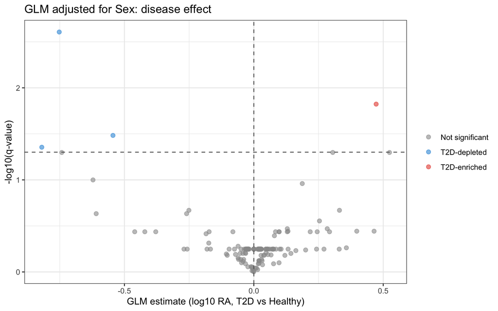

```r
glm_disease_adjusted_sex_results %>%
  mutate(
    neg_log10_q = -log10(q_value),
    direction = case_when(
      q_value < 0.05 & estimate > 0 ~ "T2D-enriched",
      q_value < 0.05 & estimate < 0 ~ "T2D-depleted",
      TRUE                          ~ "Not significant"
    )
  ) %>%
  ggplot(aes(x = estimate, y = neg_log10_q, color = direction)) +
    geom_point(alpha = 0.6, size = 2) +
    scale_color_manual(values = c("T2D-enriched" = "#E74C3C",
                                  "T2D-depleted" = "#3498DB",
                                  "Not significant" = "grey60")) +
    geom_hline(yintercept = -log10(0.05), linetype = "dashed", color = "grey40") +
    geom_vline(xintercept = 0, linetype = "dashed", color = "grey40") +
    labs(x = "GLM estimate (log10 RA, T2D vs Healthy)",
         y = "-log10(q-value)", color = NULL,
         title = "GLM adjusted for Sex: disease effect") +
    theme_bw()
```

### Bar chart — GLM adjusted top hits

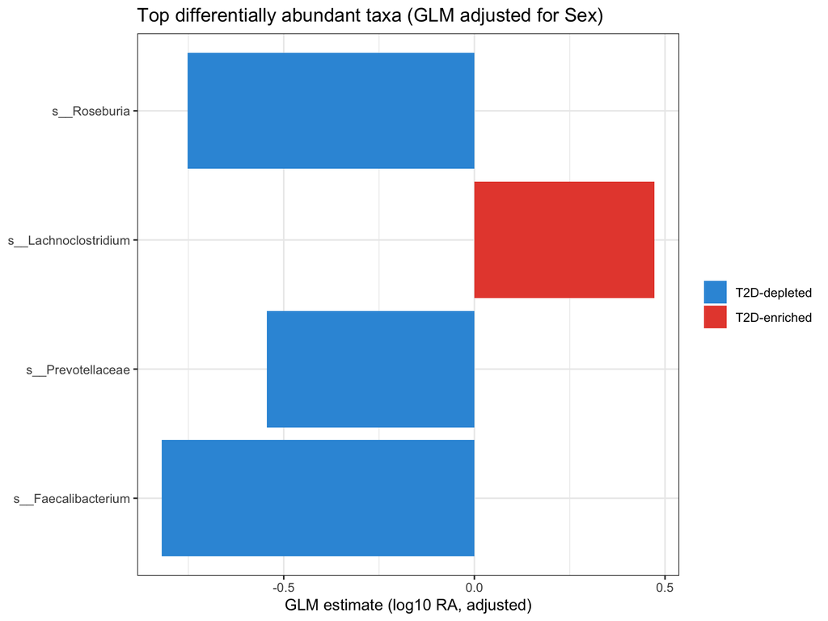

```r
bind_rows(
  glm_disease_adjusted_sex_results %>% filter(q_value < 0.05) %>% arrange(estimate)  %>% head(10),
  glm_disease_adjusted_sex_results %>% filter(q_value < 0.05) %>% arrange(-estimate) %>% head(10)
) %>%
  distinct() %>%
  mutate(
    label = Species,
    direction = ifelse(estimate > 0, "T2D-enriched", "T2D-depleted")
  ) %>%
  ggplot(aes(x = reorder(label, -q_value), y = estimate, fill = direction)) +
    geom_col() +
    coord_flip() +
    scale_fill_manual(values = c("T2D-enriched" = "#E74C3C", "T2D-depleted" = "#3498DB")) +
    labs(x = NULL, y = "GLM estimate (log10 RA, adjusted)", fill = NULL,
         title = "Top differentially abundant taxa (GLM adjusted for Sex)") +
    theme_bw()
```

## Compositional analysis with CLR transformation

```r
ps_clr <- transform_sample_counts(ps_china, function(x) {
  x <- x + 1e-9
  log(x) - mean(log(x))
})
otu_clr  <- as(otu_table(ps_clr), "matrix") %>% t() %>% as.data.frame()
meta_clr <- data.frame(sample_data(ps_clr))
tax_clr  <- as(tax_table(ps_clr), "matrix") %>% as.data.frame()
```

```r
clr_disease_adjusted_sex_results <- dat_clr %>%
  mutate(
    Disease.MESH.ID = factor(Disease.MESH.ID, levels = c("D006262", "D003924")),
    Sex             = factor(Sex,             levels = c("Female", "Male"))
  ) %>%
  group_by(taxon, Genus, Species) %>%
  group_modify(~ {
    fit <- lm(clr ~ Disease.MESH.ID + Sex, data = .x)
    broom::tidy(fit)
  }) %>%
  ungroup() %>%
  filter(term == "Disease.MESH.IDD003924") %>%
  mutate(q_value = p.adjust(p.value, method = "BH"))
```

Positive CLR estimate = T2D-enriched relative to the community geometric mean.

### Top T2D-depleted (CLR)

```r
clr_T2D_depleted <- clr_disease_adjusted_sex_results %>%
  select(taxon, Genus, Species, estimate, std.error, statistic, p.value, q_value) %>%
  arrange(estimate) %>%
  head(10)

clr_T2D_depleted
```

```
## # A tibble: 10 × 8
##    taxon  Genus             Species estimate std.error statistic p.value q_value
##    <chr>  <chr>             <chr>      <dbl>     <dbl>     <dbl>   <dbl>   <dbl>
##  1 853    g__Ruminococcace… s__Fae…    -2.97     0.895     -3.32 1.00e-3 0.0433
##  2 166486 g__Lachnospirace… s__Ros…    -2.78     0.632     -4.40 1.45e-5 0.00250
##  3 39491  g__Lachnospirace… s__unc…    -2.74     0.862     -3.18 1.59e-3 0.0472
##  4 360807 g__Lachnospirace… s__Ros…    -2.34     0.805     -2.90 3.92e-3 0.0848
##  5 821    g__Bacteroidales  s__Bac…    -2.25     0.925     -2.43 1.57e-2 0.209
##  6 363265 g__Bacteroidales  s__Pre…    -1.94     0.560     -3.46 5.96e-4 0.0343
##  7 165179 g__Bacteroidales  s__Pre…    -1.59     0.869     -1.84 6.72e-2 0.375
##  8 310297 g__Bacteroidales  s__Bac…    -1.53     0.776     -1.97 4.96e-2 0.375
##  9 310298 g__Bacteroidales  s__Bac…    -1.39     0.676     -2.05 4.07e-2 0.352
## 10 39485  g__Eubacteriaceae s__Eub…    -1.02     0.822     -1.24 2.16e-1 0.516
```

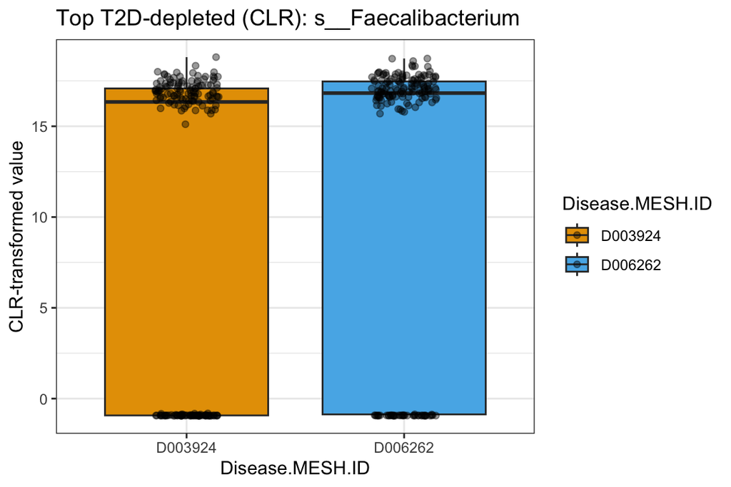

```r
top_taxon <- clr_T2D_depleted %>% slice(1) %>% pull(taxon)
top_label <- clr_T2D_depleted %>% slice(1) %>% pull(Species)

dat_clr %>%
  filter(taxon == top_taxon) %>%
  ggplot(aes(x = Disease.MESH.ID, y = clr, fill = Disease.MESH.ID)) +
    geom_boxplot(outlier.shape = NA) +
    geom_jitter(width = 0.15, alpha = 0.4) +
    scale_fill_manual(values = c("D003924" = "#E69F00", "D006262" = "#56B4E9")) +
    theme_bw() +
    labs(title = paste("Top T2D-depleted (CLR):", top_label),
         y = "CLR-transformed value")
```

### Top T2D-enriched (CLR)

```r
clr_T2D_enriched <- clr_disease_adjusted_sex_results %>%
  select(taxon, Genus, Species, estimate, std.error, statistic, p.value, q_value) %>%
  arrange(-estimate) %>%
  head(10)

clr_T2D_enriched
```

```
## # A tibble: 10 × 8
##    taxon  Genus             Species estimate std.error statistic p.value q_value
##    <chr>  <chr>             <chr>      <dbl>     <dbl>     <dbl>   <dbl>   <dbl>
##  1 216816 g__Bifidobacteri… s__Bif…     1.90     0.603      3.15 1.75e-3  0.0472
##  2 208479 g__Lachnospirace… s__Lac…     1.72     0.460      3.74 2.12e-4  0.0183
##  3 357276 g__Bacteroidales  s__Bac…     1.68     0.810      2.08 3.84e-2  0.352
##  4 46503  g__Bacteroidales  s__Tan…     1.43     0.693      2.06 4.02e-2  0.352
##  5 40518  g__Ruminococcace… s__Rum…     1.25     0.818      1.53 1.26e-1  0.516
##  6 239935 g__Akkermansiace… s__Akk…     1.17     0.479      2.44 1.54e-2  0.209
##  7 47678  g__Bacteroidales  s__Bac…     1.13     0.812      1.39 1.67e-1  0.516
##  8 1685   g__Bifidobacteri… s__Bif…     1.09     0.350      3.13 1.91e-3  0.0472
##  9 246787 g__Bacteroidales  s__Bac…     1.04     0.542      1.92 5.60e-2  0.375
## 10 39492  g__Ruminococcace… s__unc…     1.01     0.471      2.14 3.26e-2  0.352
```

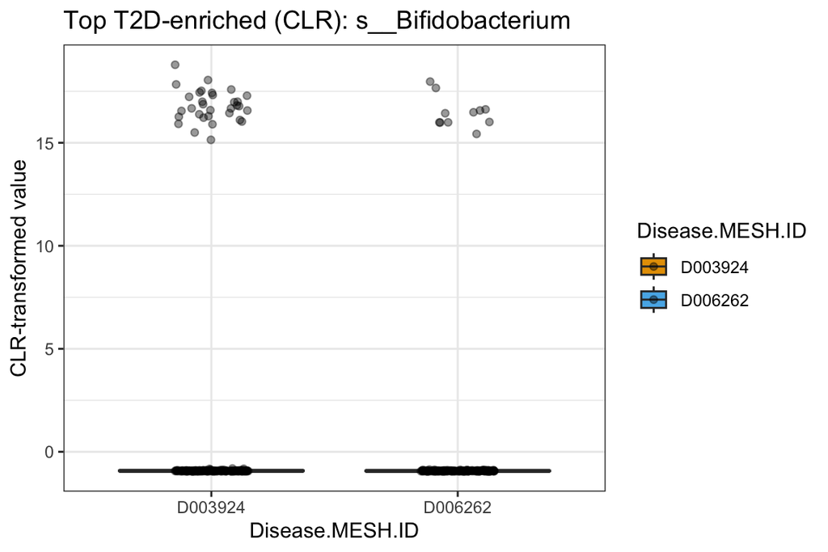

```r
top_taxon <- clr_T2D_enriched %>% slice(1) %>% pull(taxon)
top_label <- clr_T2D_enriched %>% slice(1) %>% pull(Species)

dat_clr %>%
  filter(taxon == top_taxon) %>%
  ggplot(aes(x = Disease.MESH.ID, y = clr, fill = Disease.MESH.ID)) +
    geom_boxplot(outlier.shape = NA) +
    geom_jitter(width = 0.15, alpha = 0.4) +
    scale_fill_manual(values = c("D003924" = "#E69F00", "D006262" = "#56B4E9")) +
    theme_bw() +
    labs(title = paste("Top T2D-enriched (CLR):", top_label),
         y = "CLR-transformed value")
```

### Volcano plot — CLR

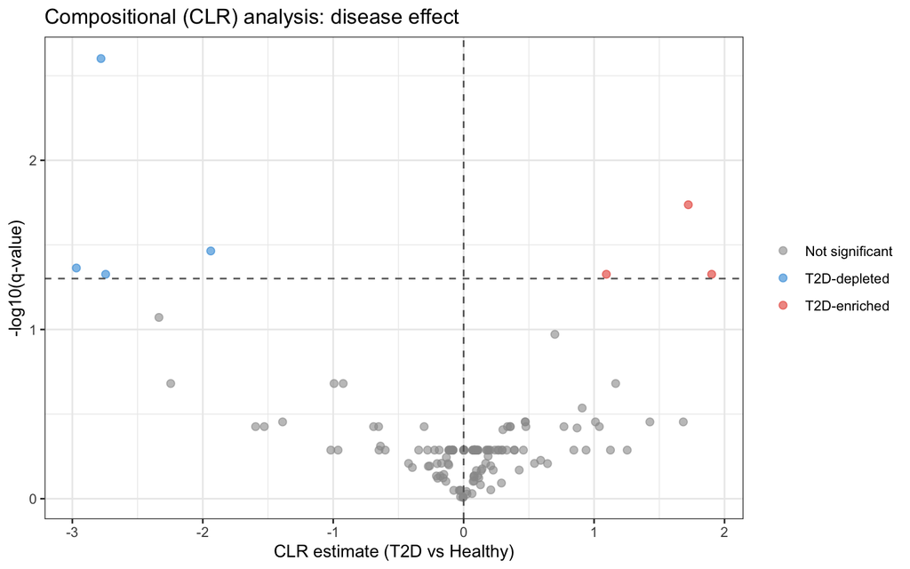

```r
clr_disease_adjusted_sex_results %>%
  mutate(
    neg_log10_q = -log10(q_value),
    direction = case_when(
      q_value < 0.05 & estimate > 0 ~ "T2D-enriched",
      q_value < 0.05 & estimate < 0 ~ "T2D-depleted",
      TRUE                          ~ "Not significant"
    )
  ) %>%
  ggplot(aes(x = estimate, y = neg_log10_q, color = direction)) +
    geom_point(alpha = 0.6, size = 2) +
    scale_color_manual(values = c("T2D-enriched" = "#E74C3C",
                                  "T2D-depleted" = "#3498DB",
                                  "Not significant" = "grey60")) +
    geom_hline(yintercept = -log10(0.05), linetype = "dashed", color = "grey40") +
    geom_vline(xintercept = 0, linetype = "dashed", color = "grey40") +
    labs(x = "CLR estimate (T2D vs Healthy)",
         y = "-log10(q-value)", color = NULL,
         title = "Compositional (CLR) analysis: disease effect") +
    theme_bw()
```

### Bar chart — CLR top hits

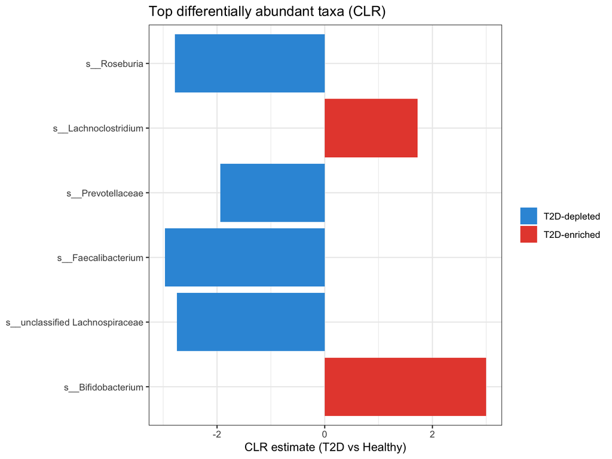

```r
bind_rows(
  clr_disease_adjusted_sex_results %>% filter(q_value < 0.05) %>% arrange(estimate)  %>% head(10),
  clr_disease_adjusted_sex_results %>% filter(q_value < 0.05) %>% arrange(-estimate) %>% head(10)
) %>%
  distinct() %>%
  mutate(
    label = Species,
    direction = ifelse(estimate > 0, "T2D-enriched", "T2D-depleted")
  ) %>%
  ggplot(aes(x = reorder(label, -q_value), y = estimate, fill = direction)) +
    geom_col() +
    coord_flip() +
    scale_fill_manual(values = c("T2D-enriched" = "#E74C3C", "T2D-depleted" = "#3498DB")) +
    labs(x = NULL, y = "CLR estimate (T2D vs Healthy)", fill = NULL,
         title = "Top differentially abundant taxa (CLR)") +
    theme_bw()
```

## Compare differential abundance methods

### Significant taxa per method

```r
sig_summary <- tibble(
  method = c("Wilcoxon", "GLM", "GLM adjusted (Sex)", "CLR adjusted (Sex)"),
  n_significant = c(
    sum(wilcox_results$q_value < 0.05, na.rm = TRUE),
    sum(glm_disease_results$q_value < 0.05, na.rm = TRUE),
    sum(glm_disease_adjusted_sex_results$q_value < 0.05, na.rm = TRUE),
    sum(clr_disease_adjusted_sex_results$q_value < 0.05, na.rm = TRUE)
  )
)

sig_summary
```

```
## # A tibble: 4 × 2
##   method             n_significant
##   <chr>                      <int>
## 1 Wilcoxon                       5
## 2 GLM                            5
## 3 GLM adjusted (Sex)             4
## 4 CLR adjusted (Sex)             7
```

### Taxa significant in all four methods

```r
all_methods_sig <- comparison_results %>%
  filter(wilcox_q < 0.05, glm_q < 0.05, glm_adj_q < 0.05, clr_q < 0.05) %>%
  select(Genus, Species, wilcox_q, glm_q, glm_adj_q, clr_q) %>%
  arrange(wilcox_q)

all_methods_sig
```

```
## # A tibble: 4 × 6
##   Genus              Species              wilcox_q   glm_q glm_adj_q   clr_q
##   <chr>              <chr>                   <dbl>   <dbl>     <dbl>   <dbl>
## 1 g__Lachnospiraceae s__Roseburia          0.00159 0.00135   0.00248 0.00250
## 2 g__Lachnospiraceae s__Lachnoclostridium  0.0199  0.0153    0.0150  0.0183
## 3 g__Ruminococcaceae s__Faecalibacterium   0.0279  0.0451    0.0442  0.0433
## 4 g__Bacteroidales   s__Prevotellaceae     0.0402  0.0451    0.0329  0.0343
```

### GLM unadjusted vs adjusted for Sex

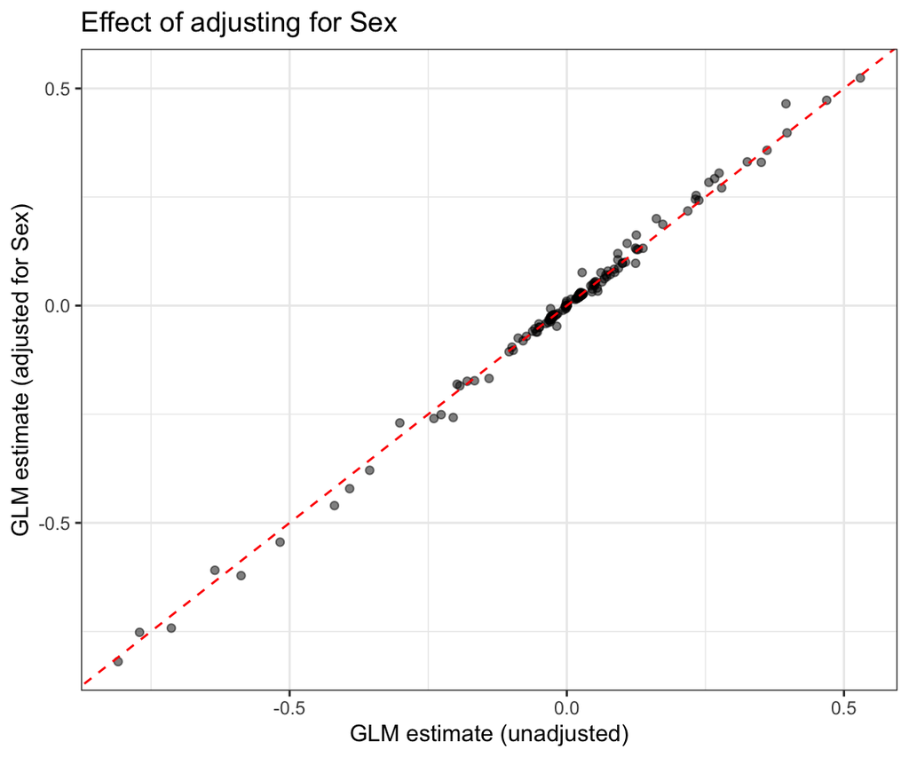

```r
comparison_results %>%
  ggplot(aes(x = glm_estimate, y = glm_adj_estimate)) +
    geom_point(alpha = 0.5) +
    geom_abline(slope = 1, intercept = 0, linetype = "dashed", color = "red") +
    labs(x = "GLM estimate (unadjusted)",
         y = "GLM estimate (adjusted for Sex)",
         title = "Effect of adjusting for Sex") +
    theme_bw()
```

### GLM adjusted vs CLR

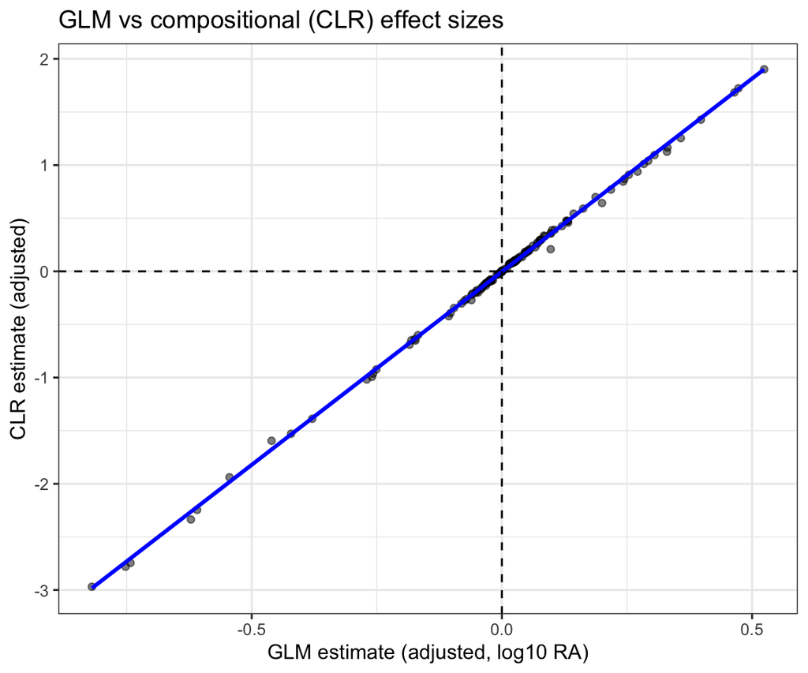

```r
comparison_results %>%
  ggplot(aes(x = glm_adj_estimate, y = clr_estimate)) +
    geom_point(alpha = 0.5) +
    geom_smooth(method = "lm", se = FALSE, color = "blue") +
    geom_hline(yintercept = 0, linetype = "dashed") +
    geom_vline(xintercept = 0, linetype = "dashed") +
    labs(x = "GLM estimate (adjusted, log10 RA)",
         y = "CLR estimate (adjusted)",
         title = "GLM vs compositional (CLR) effect sizes") +
    theme_bw()
```

### Concordance across methods

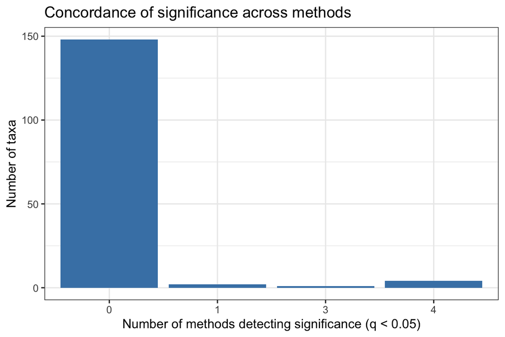

```r
comparison_results %>%
  mutate(
    sig_wilcox  = wilcox_q  < 0.05,
    sig_glm     = glm_q     < 0.05,
    sig_glm_adj = glm_adj_q < 0.05,
    sig_clr     = clr_q     < 0.05,
    n_methods_significant = sig_wilcox + sig_glm + sig_glm_adj + sig_clr
  ) %>%
  count(n_methods_significant) %>%
  filter(!is.na(n_methods_significant)) %>%
  ggplot(aes(x = factor(n_methods_significant), y = n)) +
    geom_col(fill = "steelblue") +
    labs(x = "Number of methods detecting significance (q < 0.05)",
         y = "Number of taxa",
         title = "Concordance of significance across methods") +
    theme_bw()
```

### Significance × direction heatmap

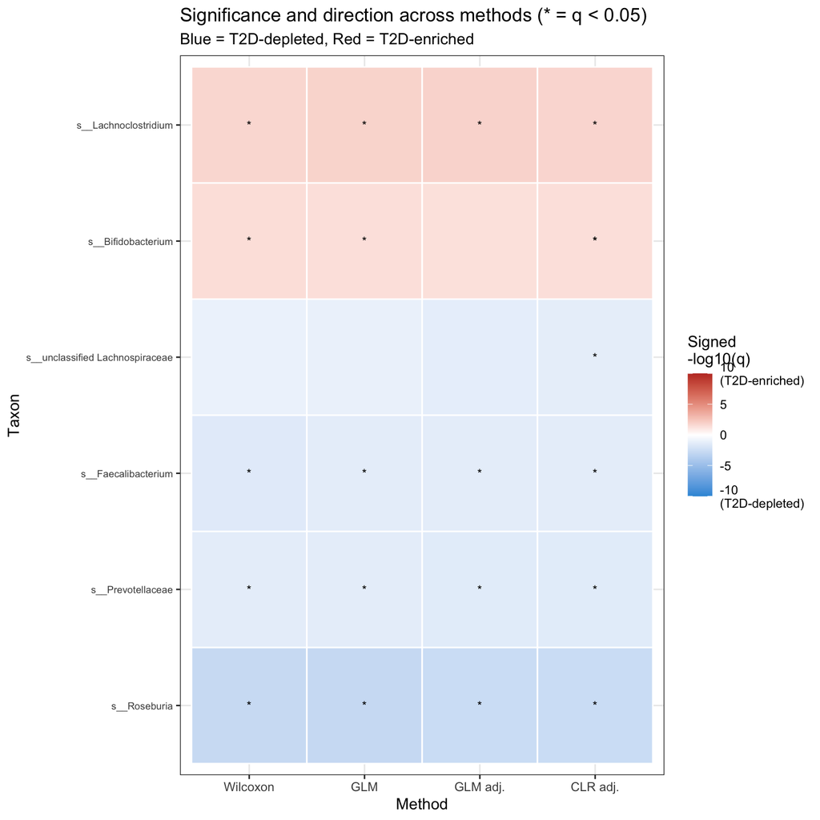

```r
heatmap_data <- comparison_results %>%
  filter(wilcox_q < 0.05 | glm_q < 0.05 | glm_adj_q < 0.05 | clr_q < 0.05) %>%
  mutate(label = Species) %>%
  select(label,
         wilcox_q, glm_q, glm_adj_q, clr_q,
         wilcox_log2fc, glm_estimate, glm_adj_estimate, clr_estimate) %>%
  pivot_longer(cols = c(wilcox_q, glm_q, glm_adj_q, clr_q),
               names_to = "method", values_to = "q_value") %>%
  mutate(
    direction = case_when(
      method == "wilcox_q"  ~ wilcox_log2fc,
      method == "glm_q"     ~ glm_estimate,
      method == "glm_adj_q" ~ glm_adj_estimate,
      method == "clr_q"     ~ clr_estimate
    ),
    signed_neg_log10_q = sign(direction) * pmin(-log10(q_value), 10),
    method = factor(method,
                    levels = c("wilcox_q", "glm_q", "glm_adj_q", "clr_q"),
                    labels = c("Wilcoxon", "GLM", "GLM adj.", "CLR adj."))
  )

taxon_order <- heatmap_data %>%
  group_by(label) %>%
  summarise(mean_signed = mean(signed_neg_log10_q, na.rm = TRUE), .groups = "drop") %>%
  arrange(mean_signed) %>%
  pull(label)

heatmap_data %>%
  mutate(label = factor(label, levels = taxon_order)) %>%
  ggplot(aes(x = method, y = label, fill = signed_neg_log10_q)) +
    geom_tile(color = "white", linewidth = 0.5) +
    geom_text(aes(label = ifelse(q_value < 0.05, "*", "")),
              color = "black", size = 3) +
    scale_fill_gradient2(
      low = "#3498DB", mid = "white", high = "#C0392B",
      midpoint = 0, limits = c(-10, 10),
      name = "Signed\n-log10(q)",
      breaks = c(-10, -5, 0, 5, 10),
      labels = c("-10\n(T2D-depleted)", "-5", "0", "5", "10\n(T2D-enriched)")
    ) +
    labs(x = "Method", y = "Taxon",
         title = "Significance and direction across methods (* = q < 0.05)",
         subtitle = "Blue = T2D-depleted, Red = T2D-enriched") +
    theme_bw() +
    theme(axis.text.y = element_text(size = 7))
```

### Wilcoxon vs CLR — sign agreement

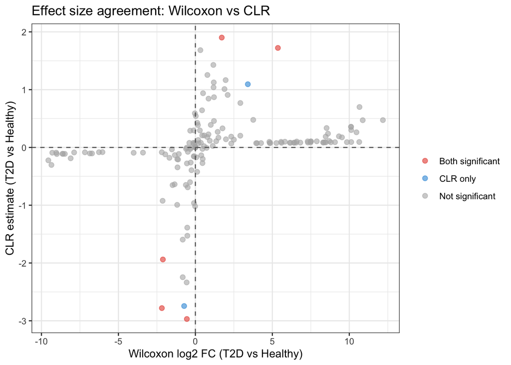

```r
comparison_results %>%
  mutate(
    sig_category = case_when(
      wilcox_q < 0.05 & clr_q < 0.05 ~ "Both significant",
      wilcox_q < 0.05                ~ "Wilcoxon only",
      clr_q < 0.05                   ~ "CLR only",
      TRUE                           ~ "Not significant"
    )
  ) %>%
  ggplot(aes(x = wilcox_log2fc, y = clr_estimate, color = sig_category)) +
    geom_point(alpha = 0.6, size = 2) +
    scale_color_manual(values = c(
      "Both significant" = "#E74C3C",
      "Wilcoxon only"    = "#E67E22",
      "CLR only"         = "#3498DB",
      "Not significant"  = "grey70"
    )) +
    geom_hline(yintercept = 0, linetype = "dashed", color = "grey40") +
    geom_vline(xintercept = 0, linetype = "dashed", color = "grey40") +
    labs(x = "Wilcoxon log2 FC (T2D vs Healthy)",
         y = "CLR estimate (T2D vs Healthy)",
         color = NULL,
         title = "Effect size agreement: Wilcoxon vs CLR") +
    theme_bw()
```

# Multivariate statistics

## PCA of CLR-transformed profiles

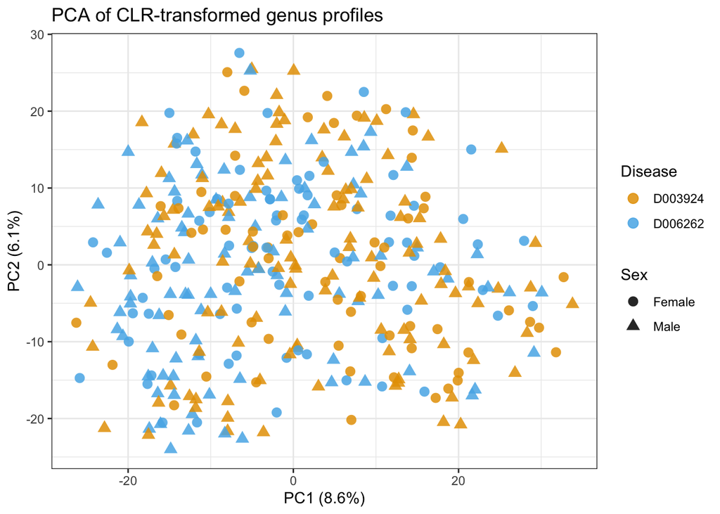

```r
clr_mat  <- otu_clr %>% as.matrix()
meta_pca <- meta_clr[rownames(clr_mat), ]

clr_pca <- prcomp(clr_mat, center = TRUE, scale. = FALSE)

pca_scores <- as.data.frame(clr_pca$x[, 1:2]) %>%
  rownames_to_column("sample_id") %>%
  left_join(meta_pca %>% rownames_to_column("sample_id"), by = "sample_id")

pca_var <- round(100 * clr_pca$sdev^2 / sum(clr_pca$sdev^2), 1)

pca_scores %>%
  ggplot(aes(x = PC1, y = PC2, color = Disease.MESH.ID, shape = Sex)) +
    geom_point(size = 3, alpha = 0.85) +
    scale_color_manual(values = c("D003924" = "#E69F00", "D006262" = "#56B4E9")) +
    scale_shape_manual(values = c("Female" = 16, "Male" = 17)) +
    labs(x = paste0("PC1 (", pca_var[1], "%)"),
         y = paste0("PC2 (", pca_var[2], "%)"),
         color = "Disease", shape = "Sex",
         title = "PCA of CLR-transformed genus profiles") +
    theme_bw()
```

## Constrained ordination with RDA

```r
rda_disease <- rda(clr_mat ~ Disease.MESH.ID + Sex, data = meta_pca)
```

### Permutation tests

```r
anova(rda_disease, permutations = 999)
```

```
## Permutation test for rda under reduced model
## Permutation: free
## Number of permutations: 999
##
## Model: rda(formula = clr_mat ~ Disease.MESH.ID + Sex, data = meta_pca)
##           Df Variance      F Pr(>F)
## Model      2    28.09 2.3211  0.001 ***
## Residual 356  2154.49
## ---
## Signif. codes:  0 '***' 0.001 '**' 0.01 '*' 0.05 '.' 0.1 ' ' 1
```

```r
anova(rda_disease, by = "term", permutations = 999)
```

```
## Permutation test for rda under reduced model
## Terms added sequentially (first to last)
## Permutation: free
## Number of permutations: 999
##
## Model: rda(formula = clr_mat ~ Disease.MESH.ID + Sex, data = meta_pca)
##                  Df Variance      F Pr(>F)
## Disease.MESH.ID   1    18.90 3.1236  0.001 ***
## Sex               1     9.19 1.5186  0.023 *
## Residual        356  2154.49
## ---
## Signif. codes:  0 '***' 0.001 '**' 0.01 '*' 0.05 '.' 0.1 ' ' 1
```

A significant disease term supports a community-level disease effect after accounting for sex.

### Top RDA1 taxa

```r
rda_site_scores_raw <- scores(rda_disease, display = "sites")
rda1_sign <- ifelse(
  mean(rda_site_scores_raw[meta_pca$Disease.MESH.ID == "D003924", "RDA1"], na.rm = TRUE) >=
    mean(rda_site_scores_raw[meta_pca$Disease.MESH.ID == "D006262", "RDA1"], na.rm = TRUE),
  1, -1
)

taxon_scores <- scores(rda_disease, display = "species")[, 1] * rda1_sign

rda_taxa <- tibble(
  taxon        = names(taxon_scores),
  rda1_loading = taxon_scores
) %>%
  arrange(desc(abs(rda1_loading)))
```

### RDA biplot

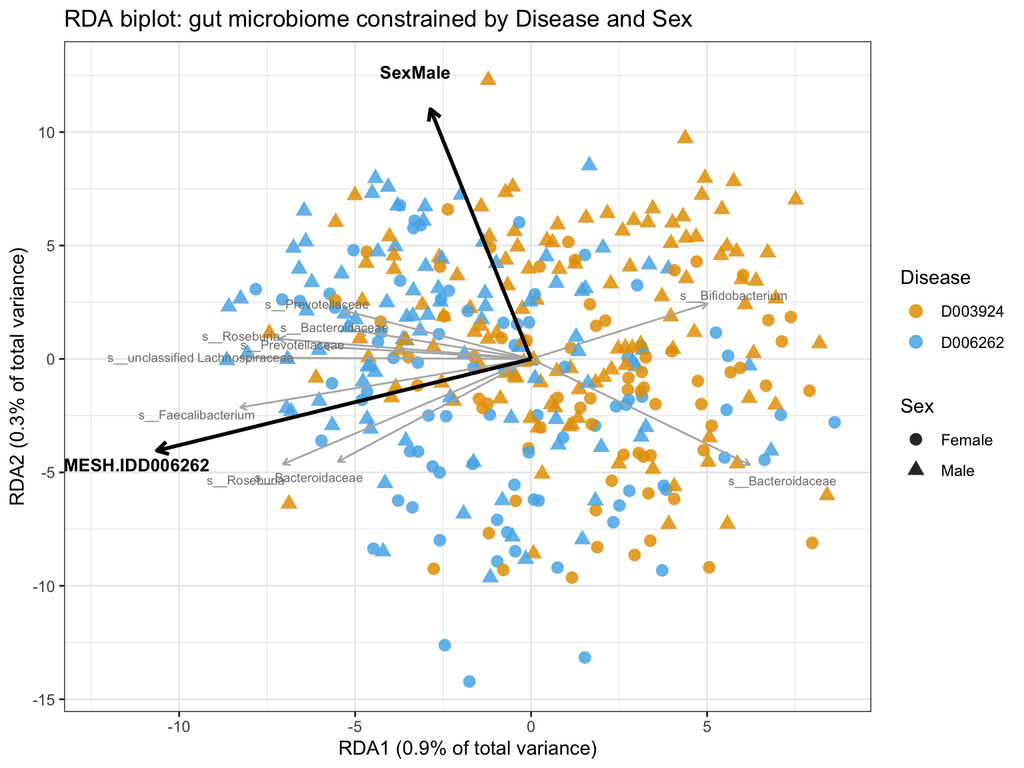

```r
eig <- rda_disease$CCA$eig
pct1 <- round(eig[1] / rda_disease$tot.chi * 100, 1)
pct2 <- round(eig[2] / rda_disease$tot.chi * 100, 1)

site_scores <- scores(rda_disease, display = "sites") %>%
  as.data.frame() %>%
  mutate(RDA1 = RDA1 * rda1_sign) %>%
  rownames_to_column("sample_id") %>%
  left_join(meta_pca %>% rownames_to_column("sample_id"), by = "sample_id")

biplot_scores <- scores(rda_disease, display = "bp") %>%
  as.data.frame() %>%
  mutate(RDA1 = RDA1 * rda1_sign) %>%
  rownames_to_column("variable")

top_species_scores <- scores(rda_disease, display = "species") %>%
  as.data.frame() %>%
  mutate(RDA1 = RDA1 * rda1_sign) %>%
  rownames_to_column("taxon") %>%
  inner_join(rda_taxa %>% head(10), by = "taxon") %>%
  left_join(tax_clr %>% rownames_to_column("taxon"), by = "taxon") %>%
  mutate(label = Species)

site_range    <- max(abs(c(site_scores$RDA1, site_scores$RDA2)))
arrow_scale   <- site_range * 0.8 / max(sqrt(biplot_scores$RDA1^2 + biplot_scores$RDA2^2))
species_scale <- site_range * 0.6 / max(sqrt(top_species_scores$RDA1^2 + top_species_scores$RDA2^2))

biplot_scores      <- biplot_scores      %>% mutate(RDA1 = RDA1 * arrow_scale,   RDA2 = RDA2 * arrow_scale)
top_species_scores <- top_species_scores %>% mutate(RDA1 = RDA1 * species_scale, RDA2 = RDA2 * species_scale)

ggplot() +
  geom_point(data = site_scores,
             aes(x = RDA1, y = RDA2, color = Disease.MESH.ID, shape = Sex),
             size = 3, alpha = 0.85) +
  geom_segment(data = top_species_scores,
               aes(x = 0, y = 0, xend = RDA1, yend = RDA2),
               arrow = arrow(length = unit(0.15, "cm")),
               color = "grey70", linewidth = 0.5) +
  geom_text(data = top_species_scores,
            aes(x = RDA1 * 1.15, y = RDA2 * 1.15, label = label),
            size = 2.5, color = "grey50") +
  geom_segment(data = biplot_scores,
               aes(x = 0, y = 0, xend = RDA1, yend = RDA2),
               arrow = arrow(length = unit(0.25, "cm")),
               color = "black", linewidth = 1) +
  geom_text(data = biplot_scores,
            aes(x = RDA1 * 1.15, y = RDA2 * 1.15, label = variable),
            size = 3.5, fontface = "bold", color = "black") +
  scale_color_manual(values = c("D003924" = "#E69F00", "D006262" = "#56B4E9")) +
  scale_shape_manual(values = c("Female" = 16, "Male" = 17)) +
  labs(x = paste0("RDA1 (", pct1, "% of total variance)"),
       y = paste0("RDA2 (", pct2, "% of total variance)"),
       color = "Disease", shape = "Sex",
       title = "RDA biplot: gut microbiome constrained by Disease and Sex") +
  theme_bw()
```